# Marsh_dataviz_Mini_Project_1_Late

Henry Marsh

# Mini-Project 1

If you want to go straight to parts 6 and 7 on the instruction, please scroll to the bottom or navigate on the left to there.

# Packages

```r
library(tidyverse)
library(lubridate)
library(janitor)
library(scales)
library(viridis)
library(plotly)
library(leaflet)
library(leaflet.extras)
library(DT)
```

# Data Loading

```r
rats <- "https://data.cityofnewyork.us/resource/gj6a-xguv.csv?$limit=50000&$order=created_date%20DESC"

rats <- read_csv(rats, show_col_types = FALSE) %>%
  clean_names()

glimpse(rats)
```

```
## Rows: 1,397
## Columns: 38
## $ unique_key                     <dbl> 69466241, 69458821, 69393897, 69374275,…
## $ created_date                   <dttm> 2026-06-23 21:59:30, 2026-06-23 06:06:…
## $ closed_date                    <dttm> NA, NA, NA, NA, NA, NA, 2026-06-18 19:…
## $ agency                         <chr> "DOHMH", "DOHMH", "DOHMH", "DOHMH", "DO…
## $ agency_name                    <chr> "Department of Health and Mental Hygien…
## $ complaint_type                 <chr> "Rodent", "Rodent", "Rodent", "Rodent",…
## $ descriptor                     <chr> "Rat Sighting", "Rat Sighting", "Rat Si…
## $ location_type                  <chr> "Commercial Building", "3+ Family Apt. …
## $ incident_zip                   <dbl> 11214, 11223, 11223, 11214, 11214, 1121…
## $ incident_address               <chr> "2535 86 STREET", "1684 WEST 10 STREET"…
## $ street_name                    <chr> "86 STREET", "WEST 10 STREET", "AVENUE …
## $ cross_street_1                 <chr> "BAY 40 STREET", "AVENUE P", "WEST 12 S…
## $ cross_street_2                 <chr> "BAY 41 STREET", "KINGS HIGHWAY", "WEST…
```

[output cut: 25 more lines]

# Data Cleaning and Prep

```r
rats_clean <- rats %>%
  mutate(
    created_date = ymd_hms(created_date, quiet = TRUE),
    closed_date = ymd_hms(closed_date, quiet = TRUE),

    created_day = as_date(created_date),
    created_month = floor_date(created_date, "month"),
    created_year = year(created_date),
    created_hour = hour(created_date),

    sighting_year = year(created_date),
    sighting_month_num = month(created_date),
    sighting_month = factor(
      month.name[sighting_month_num],
      levels = month.name
    ),
    sighting_day = day(created_date),
    sighting_weekday = factor(
      wday(created_date, label = TRUE, abbr = FALSE),
      levels = c("Monday", "Tuesday", "Wednesday", "Thursday", "Friday", "Saturday", "Sunday")
    ),

    borough = str_to_title(borough),
    borough = na_if(borough, "Unspecified"),

    incident_zip = as.character(incident_zip),
    location_type = str_to_title(location_type),
    descriptor = str_to_title(descriptor),
    status = str_to_title(status),

    response_days = as.numeric(difftime(closed_date, created_date, units = "days"))
  )

rats_geo <- rats_clean %>%
  filter(
    !is.na(latitude),
    !is.na(longitude),
    latitude >= 40,
    latitude <= 41,
    longitude >= -75,
    longitude <= -73
  )

glimpse(rats_clean)
```

```
## Rows: 1,397
## Columns: 48
## $ unique_key                     <dbl> 69466241, 69458821, 69393897, 69374275,…
## $ created_date                   <dttm> 2026-06-23 21:59:30, 2026-06-23 06:06:…
## $ closed_date                    <dttm> NA, NA, NA, NA, NA, NA, 2026-06-18 19:…
## $ agency                         <chr> "DOHMH", "DOHMH", "DOHMH", "DOHMH", "DO…
## $ agency_name                    <chr> "Department of Health and Mental Hygien…
## $ complaint_type                 <chr> "Rodent", "Rodent", "Rodent", "Rodent",…
## $ descriptor                     <chr> "Rat Sighting", "Rat Sighting", "Rat Si…
## $ location_type                  <chr> "Commercial Building", "3+ Family Apt. …
## $ incident_zip                   <chr> "11214", "11223", "11223", "11214", "11…
## $ incident_address               <chr> "2535 86 STREET", "1684 WEST 10 STREET"…
## $ street_name                    <chr> "86 STREET", "WEST 10 STREET", "AVENUE …
## $ cross_street_1                 <chr> "BAY 40 STREET", "AVENUE P", "WEST 12 S…
## $ cross_street_2                 <chr> "BAY 41 STREET", "KINGS HIGHWAY", "WEST…
```

[output cut: 35 more lines]

# summary

```r
summary_table <- tibble(
  measure = c(
    "Total records",
    "Unique complaint IDs",
    "Records with latitude/longitude",
    "Unique boroughs",
    "Unique ZIP codes",
    "Earliest report date",
    "Latest report date"
  ),
  value = c(
    nrow(rats_clean),
    n_distinct(rats_clean$unique_key),
    nrow(rats_clean %>% filter(!is.na(latitude), !is.na(longitude))),
    n_distinct(rats_clean$borough, na.rm = TRUE),
    n_distinct(rats_clean$incident_zip, na.rm = TRUE),
    as.character(min(rats_clean$created_day, na.rm = TRUE)),
    as.character(max(rats_clean$created_day, na.rm = TRUE))
  )
)

summary_table
```

```
## # A tibble: 7 × 2
##   measure                         value
##   <chr>                           <chr>
## 1 Total records                   1397
## 2 Unique complaint IDs            1397
## 3 Records with latitude/longitude 1389
## 4 Unique boroughs                 1
## 5 Unique ZIP codes                6
## 6 Earliest report date            2020-01-12
## 7 Latest report date              2026-06-23
```

# Geographic Filter

```r
rats_geo <- rats_clean %>%
  filter(
    !is.na(latitude),
    !is.na(longitude))

glimpse(rats_geo)
```

```
## Rows: 1,389
## Columns: 48
## $ unique_key                     <dbl> 69466241, 69458821, 69393897, 69374275,…
## $ created_date                   <dttm> 2026-06-23 21:59:30, 2026-06-23 06:06:…
## $ closed_date                    <dttm> NA, NA, NA, NA, NA, NA, 2026-06-18 19:…
## $ agency                         <chr> "DOHMH", "DOHMH", "DOHMH", "DOHMH", "DO…
## $ agency_name                    <chr> "Department of Health and Mental Hygien…
## $ complaint_type                 <chr> "Rodent", "Rodent", "Rodent", "Rodent",…
## $ descriptor                     <chr> "Rat Sighting", "Rat Sighting", "Rat Si…
## $ location_type                  <chr> "Commercial Building", "3+ Family Apt. …
## $ incident_zip                   <chr> "11214", "11223", "11223", "11214", "11…
## $ incident_address               <chr> "2535 86 STREET", "1684 WEST 10 STREET"…
## $ street_name                    <chr> "86 STREET", "WEST 10 STREET", "AVENUE …
## $ cross_street_1                 <chr> "BAY 40 STREET", "AVENUE P", "WEST 12 S…
## $ cross_street_2                 <chr> "BAY 41 STREET", "KINGS HIGHWAY", "WEST…
```

[output cut: 35 more lines]

# Exploratory Data Analysis

```r
eda_theme <- theme_minimal(base_size = 13) +
  theme(
    plot.title = element_text(face = "bold"),
    plot.title.position = "plot",
    panel.grid.minor = element_blank()
  )
```

## Data Overview

```r
summary_table <- tibble(
  measure = c(
    "Total records",
    "Unique complaint IDs",
    "Duplicate complaint IDs",
    "Records with coordinates",
    "Unique boroughs",
    "Unique ZIP codes",
    "Earliest report date",
    "Latest report date"
  ),
  value = c(
    nrow(rats_clean),
    n_distinct(rats_clean$unique_key),
    nrow(rats_clean) - n_distinct(rats_clean$unique_key),
    nrow(rats_clean %>% filter(!is.na(latitude), !is.na(longitude))),
    n_distinct(rats_clean$borough, na.rm = TRUE),
    n_distinct(rats_clean$incident_zip, na.rm = TRUE),
    as.character(min(rats_clean$created_day, na.rm = TRUE)),
    as.character(max(rats_clean$created_day, na.rm = TRUE))
  )
)

summary_table
```

```
## # A tibble: 8 × 2
##   measure                  value
##   <chr>                    <chr>
## 1 Total records            1397
## 2 Unique complaint IDs     1397
## 3 Duplicate complaint IDs  0
## 4 Records with coordinates 1389
## 5 Unique boroughs          1
## 6 Unique ZIP codes         6
## 7 Earliest report date     2020-01-12
## 8 Latest report date       2026-06-23
```

## Missing Values

```r
missing_summary <- rats_clean %>%
  select(
    unique_key,
    created_date,
    closed_date,
    borough,
    incident_zip,
    location_type,
    descriptor,
    status,
    latitude,
    longitude,
    response_days
  ) %>%
  summarise(across(everything(), ~ sum(is.na(.)))) %>%
  pivot_longer(
    cols = everything(),
    names_to = "variable",
    values_to = "missing_count"
  ) %>%
  mutate(
    missing_percent = round(missing_count / nrow(rats_clean) * 100, 2)
  ) %>%
  arrange(desc(missing_count))

missing_summary
```

```
## # A tibble: 11 × 3
##    variable      missing_count missing_percent
##    <chr>                 <int>           <dbl>
##  1 closed_date              92            6.59
##  2 response_days            92            6.59
##  3 latitude                  8            0.57
##  4 longitude                 8            0.57
##  5 unique_key                0            0
##  6 created_date              0            0
##  7 borough                   0            0
##  8 incident_zip              0            0
##  9 location_type             0            0
## 10 descriptor                0            0
## 11 status                    0            0
```

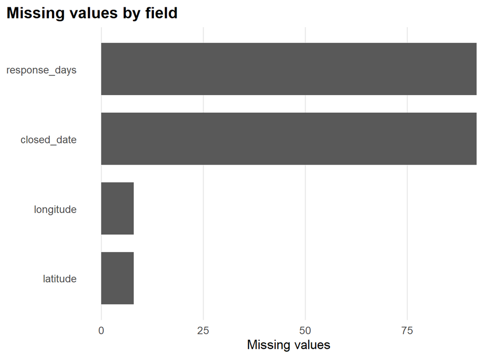

```r
missing_summary %>%
  filter(missing_count > 0) %>%
  mutate(variable = fct_reorder(variable, missing_count)) %>%
  ggplot(aes(x = variable, y = missing_count)) +
  geom_col(width = 0.75) +
  coord_flip() +
  scale_y_continuous(labels = comma) +
  labs(
    title = "Missing values by field",
    x = NULL,
    y = "Missing values"
  ) +
  eda_theme +
  theme(panel.grid.major.y = element_blank())
```

## Borough Distribution

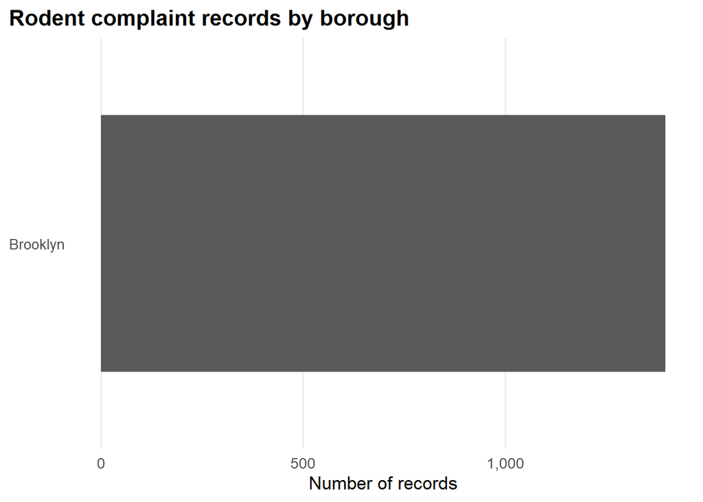

```r
borough_counts <- rats_clean %>%
  filter(!is.na(borough)) %>%
  count(borough, sort = TRUE) %>%
  mutate(
    percent_share = n / sum(n),
    borough = fct_reorder(borough, n)
  )

borough_counts %>%
  ggplot(aes(x = borough, y = n)) +
  geom_col(width = 0.75) +
  coord_flip() +
  scale_y_continuous(labels = comma) +
  labs(
    title = "Rodent complaint records by borough",
    x = NULL,
    y = "Number of records"
  ) +
  eda_theme +
  theme(panel.grid.major.y = element_blank())
```

```r
borough_counts %>%
  arrange(desc(n)) %>%
  mutate(percent_share = percent(percent_share, accuracy = 0.1))
```

```
## # A tibble: 1 × 3
##   borough      n percent_share
##   <fct>    <int> <chr>
## 1 Brooklyn  1397 100.0%
```

making sure no reported areas are outside the range given

## Top ZIP Codes

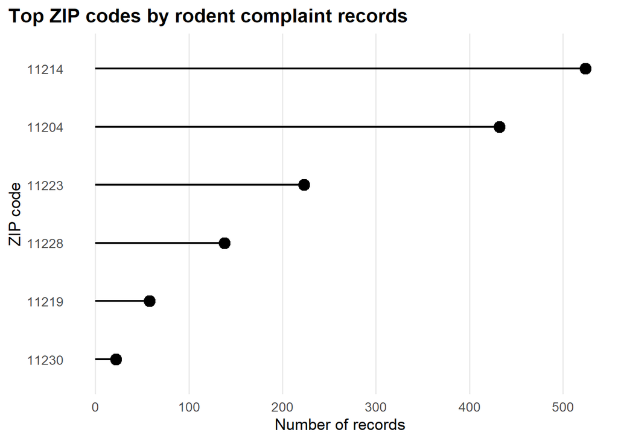

```r
top_zips <- rats_clean %>%
  filter(!is.na(incident_zip), incident_zip != "NA") %>%
  count(incident_zip, sort = TRUE) %>%
  slice_max(n, n = 15) %>%
  mutate(incident_zip = fct_reorder(incident_zip, n))

ggplot(top_zips, aes(x = incident_zip, y = n)) +
  geom_segment(
    aes(x = incident_zip, xend = incident_zip, y = 0, yend = n),
    linewidth = 0.8
  ) +
  geom_point(size = 4) +
  coord_flip() +
  scale_y_continuous(labels = comma) +
  labs(
    title = "Top ZIP codes by rodent complaint records",
    x = "ZIP code",
    y = "Number of records"
  ) +
  eda_theme +
  theme(panel.grid.major.y = element_blank())
```

ZIP codes provide a little more detailed view than boroughs, I was doing this to see how different area density is within the area.

## Location Type

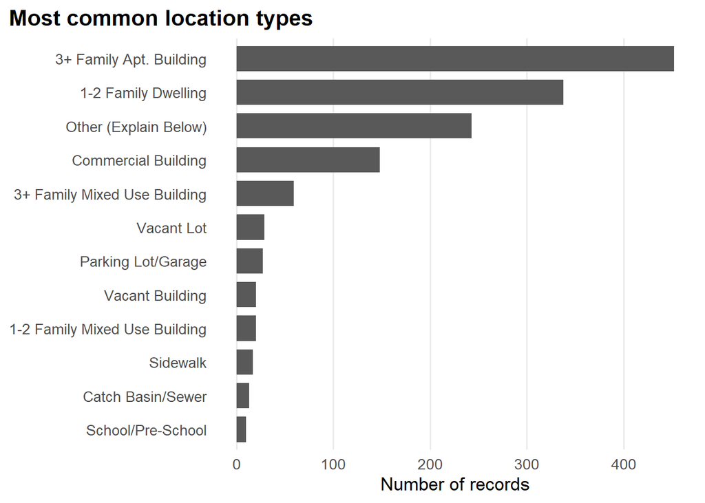

```r
location_counts <- rats_clean %>%
  filter(!is.na(location_type), location_type != "Unspecified") %>%
  count(location_type, sort = TRUE) %>%
  slice_max(n, n = 12) %>%
  mutate(location_type = fct_reorder(location_type, n))

ggplot(location_counts, aes(x = location_type, y = n)) +
  geom_col(width = 0.75) +
  coord_flip() +
  scale_y_continuous(labels = comma) +
  labs(
    title = "Most common location types",
    x = NULL,
    y = "Number of records"
  ) +
  eda_theme +
  theme(panel.grid.major.y = element_blank())
```

Location type for context as to where complaints are being reported.

## Complaint Status

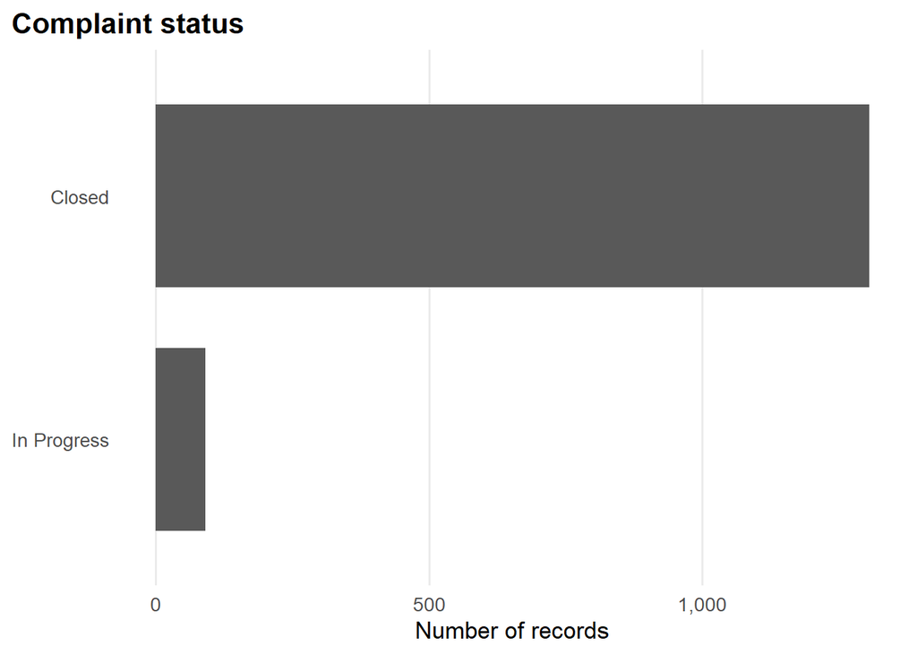

```r
status_counts <- rats_clean %>%
  filter(!is.na(status)) %>%
  count(status, sort = TRUE) %>%
  mutate(
    percent_share = n / sum(n),
    status = fct_reorder(status, n)
  )

ggplot(status_counts, aes(x = status, y = n)) +
  geom_col(width = 0.75) +
  coord_flip() +
  scale_y_continuous(labels = comma) +
  labs(
    title = "Complaint status",
    x = NULL,
    y = "Number of records"
  ) +
  eda_theme +
  theme(panel.grid.major.y = element_blank())
```

```r
status_counts %>%
  arrange(desc(n)) %>%
  mutate(percent_share = percent(percent_share, accuracy = 0.1))
```

```
## # A tibble: 2 × 3
##   status          n percent_share
##   <fct>       <int> <chr>
## 1 Closed       1305 93.4%
## 2 In Progress    92 6.6%
```

Lets me know if some records do not have response times yet, and thus need to be excluded pending on graph.

## Time Patterns

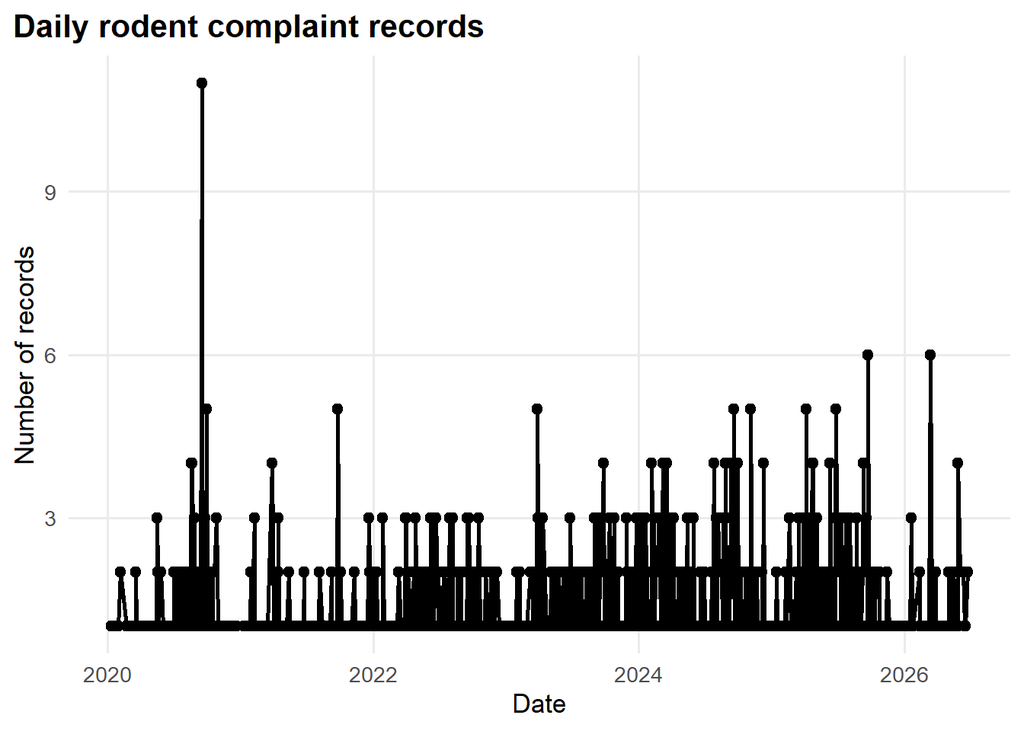

```r
daily_counts <- rats_clean %>%
  filter(!is.na(created_day)) %>%
  count(created_day)

ggplot(daily_counts, aes(x = created_day, y = n)) +
  geom_line(linewidth = 1) +
  geom_point(size = 2) +
  scale_y_continuous(labels = comma) +
  labs(
    title = "Daily rodent complaint records",
    x = "Date",
    y = "Number of records"
  ) +
  eda_theme
```

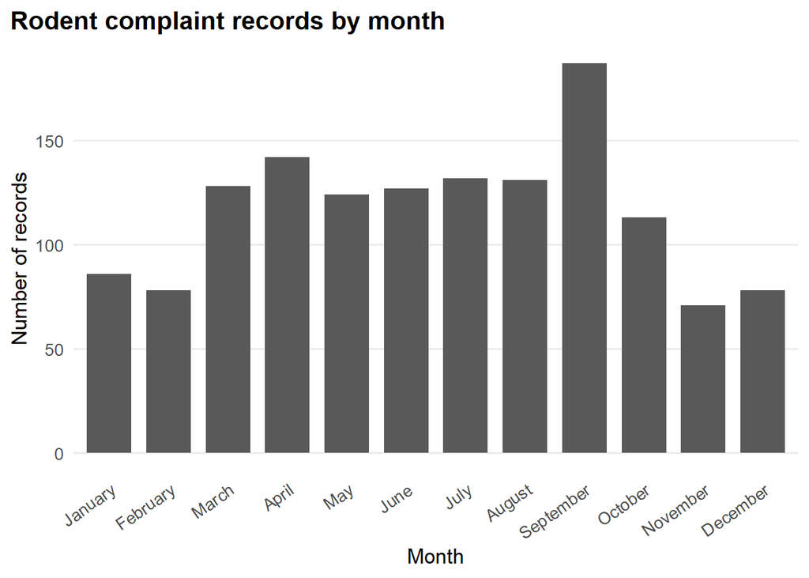

```r
month_counts <- rats_clean %>%
  filter(!is.na(sighting_month)) %>%
  count(sighting_month)

ggplot(month_counts, aes(x = sighting_month, y = n)) +
  geom_col(width = 0.75) +
  scale_y_continuous(labels = comma) +
  labs(
    title = "Rodent complaint records by month",
    x = "Month",
    y = "Number of records"
  ) +
  eda_theme +
  theme(
    axis.text.x = element_text(angle = 35, hjust = 1),
    panel.grid.major.x = element_blank()
  )
```

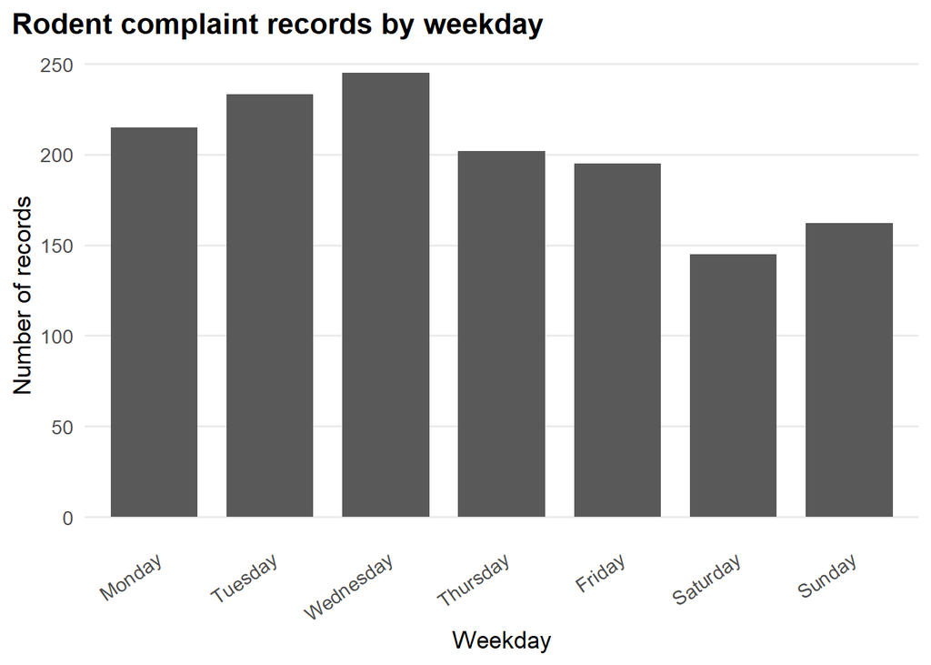

```r
weekday_counts <- rats_clean %>%
  filter(!is.na(sighting_weekday)) %>%
  count(sighting_weekday)

ggplot(weekday_counts, aes(x = sighting_weekday, y = n)) +
  geom_col(width = 0.75) +
  scale_y_continuous(labels = comma) +
  labs(
    title = "Rodent complaint records by weekday",
    x = "Weekday",
    y = "Number of records"
  ) +
  eda_theme +
  theme(
    axis.text.x = element_text(angle = 35, hjust = 1),
    panel.grid.major.x = element_blank()
  )
```

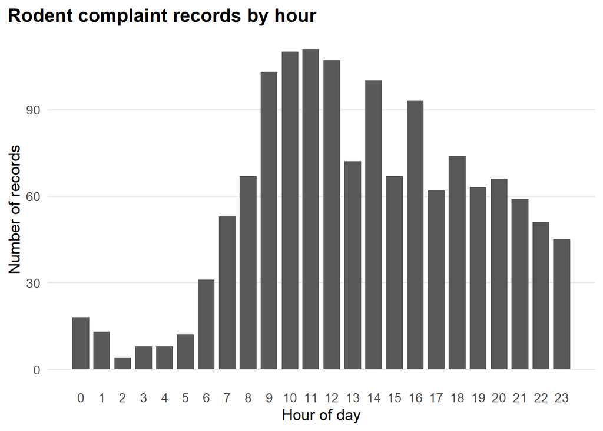

```r
hour_counts <- rats_clean %>%
  filter(!is.na(created_hour)) %>%
  count(created_hour) %>%
  complete(created_hour = 0:23, fill = list(n = 0))

ggplot(hour_counts, aes(x = created_hour, y = n)) +
  geom_col(width = 0.8) +
  scale_x_continuous(breaks = 0:23) +
  scale_y_continuous(labels = comma) +
  labs(
    title = "Rodent complaint records by hour",
    x = "Hour of day",
    y = "Number of records"
  ) +
  eda_theme +
  theme(panel.grid.major.x = element_blank())
```

Unsuprisingly we see that the peek complaint times mirror that of 9 am to 6 pm.

## Month and Weekday Heatmap

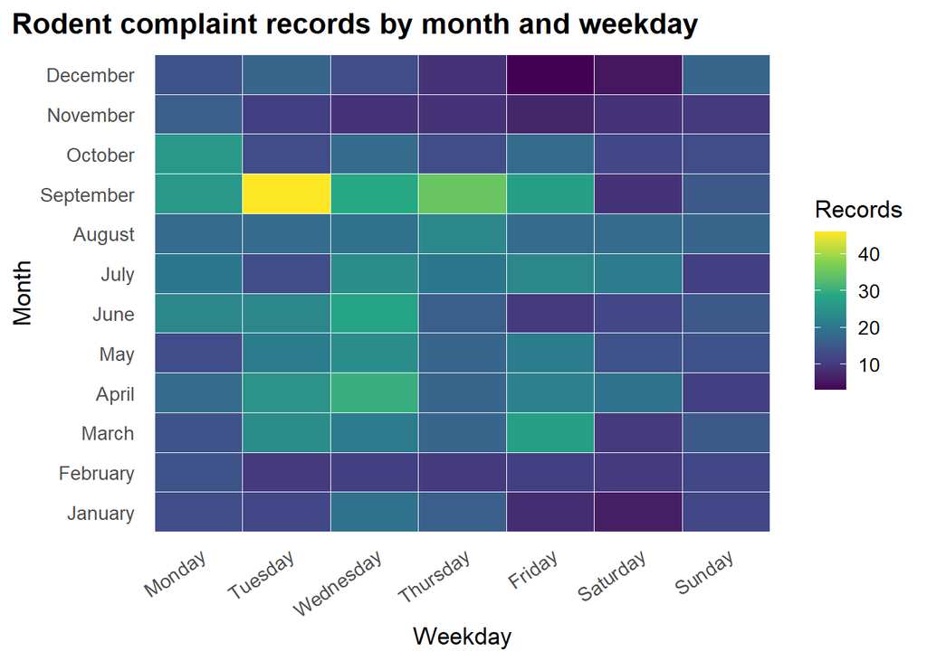

```r
month_weekday <- rats_clean %>%
  filter(!is.na(sighting_month), !is.na(sighting_weekday)) %>%
  count(sighting_month, sighting_weekday)

ggplot(month_weekday, aes(x = sighting_weekday, y = sighting_month, fill = n)) +
  geom_tile(color = "white", linewidth = 0.3) +
  scale_fill_viridis_c(labels = comma) +
  labs(
    title = "Rodent complaint records by month and weekday",
    x = "Weekday",
    y = "Month",
    fill = "Records"
  ) +
  eda_theme +
  theme(
    axis.text.x = element_text(angle = 35, hjust = 1),
    panel.grid = element_blank()
  )
```

The heatmap makes it easier to compare two time categories at once and see which combinations have the most reports. Thus allowing us to see very interesting relationships.

## Response Time

```r
response_summary <- rats_clean %>%
  filter(!is.na(response_days), response_days >= 0) %>%
  summarise(
    completed_reports = n(),
    min_days = min(response_days, na.rm = TRUE),
    median_days = median(response_days, na.rm = TRUE),
    mean_days = mean(response_days, na.rm = TRUE),
    max_days = max(response_days, na.rm = TRUE)
  )

response_summary
```

```
## # A tibble: 1 × 5
##   completed_reports min_days median_days mean_days max_days
##               <int>    <dbl>       <dbl>     <dbl>    <dbl>
## 1              1305        0           0      5.04     175.
```

## Spatial Pattern

```r
coordinate_summary <- rats_clean %>%
  filter(!is.na(latitude), !is.na(longitude)) %>%
  summarise(
    records_with_coordinates = n(),
    min_latitude = min(latitude, na.rm = TRUE),
    max_latitude = max(latitude, na.rm = TRUE),
    min_longitude = min(longitude, na.rm = TRUE),
    max_longitude = max(longitude, na.rm = TRUE)
  )

coordinate_summary
```

```
## # A tibble: 1 × 5
##   records_with_coordinates min_latitude max_latitude min_longitude max_longitude
##                      <int>        <dbl>        <dbl>         <dbl>         <dbl>
## 1                     1389         40.6         40.6         -74.0         -74.0
```

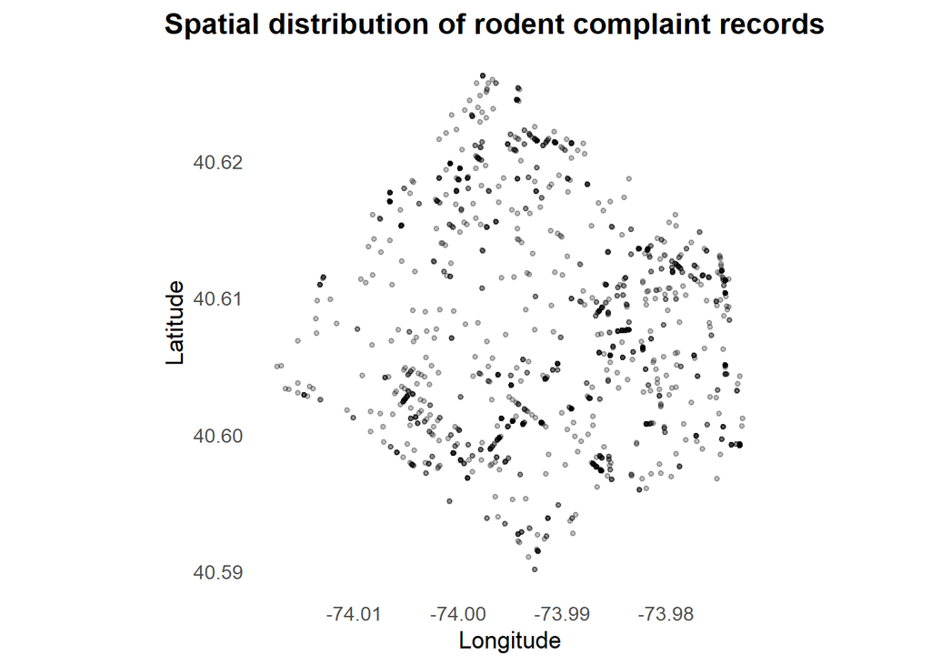

```r
rats_coordinates <- rats_clean %>%
  filter(!is.na(latitude), !is.na(longitude))

ggplot(rats_coordinates, aes(x = longitude, y = latitude)) +
  geom_point(alpha = 0.25, size = 1) +
  coord_quickmap() +
  labs(
    title = "Spatial distribution of rodent complaint records",
    x = "Longitude",
    y = "Latitude"
  ) +
  eda_theme +
  theme(panel.grid = element_blank())
```

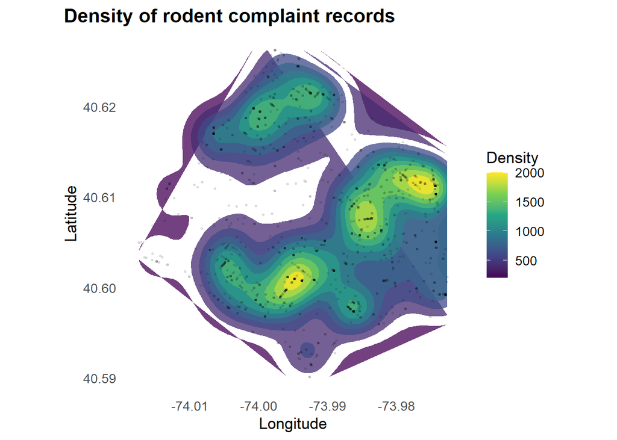

```r
ggplot(rats_coordinates, aes(x = longitude, y = latitude)) +
  stat_density_2d(
    aes(fill = after_stat(level)),
    geom = "polygon",
    alpha = 0.75
  ) +
  geom_point(alpha = 0.08, size = 0.5) +
  scale_fill_viridis_c() +
  coord_quickmap() +
  labs(
    title = "Density of rodent complaint records",
    x = "Longitude",
    y = "Latitude",
    fill = "Density"
  ) +
  eda_theme +
  theme(panel.grid = element_blank())
```

## Density Heatmap on NYC Map

```r
rats_coordinates <- rats_clean %>%
  filter(!is.na(latitude), !is.na(longitude))

leaflet(rats_coordinates) %>%
  addProviderTiles(providers$CartoDB.Positron) %>%
  setView(lng = -73.95, lat = 40.72, zoom = 11) %>%
  addHeatmap(
    lng = ~longitude,
    lat = ~latitude,
    blur = 20,
    radius = 15,
    max = 0.05
  )
```

[interactive chart not shown]